# Practical Machine Learning

## Introduction

This write-up describes an analysis of the Weight Lifting Exercise Dataset using a machine learning classifier. Taking data from accelerometers on the belt, forearm, arm and dumbbell of 6 participants, a random forest algorithm was able to classify the type of barbell lift performed with an estimated >99% out-of-sample accuracy.

## Data Preparation

The libraries required are loaded in.

```r
library(lattice)
library(ggplot2)
library(caret)
library(randomForest)
library(rpart)
library(gbm)
library(plyr)
```

First we load in the training data and set the seed. We partition it into main (80%) and reserve (20%) data. By doing so, we can do the bulk of the training on main using cross-validation, then estimate the out-of-sample error on reserve.

```r
#read in training data
training <- read.csv("https://d396qusza40orc.cloudfront.net/predmachlearn/pml-training.csv")
set.seed(1000)
inTrain <- createDataPartition(training$classe, p = 0.8)[[1]]
trainingReserve <- training[-inTrain, ]
trainingMain <- training[inTrain, ]
```

Let’s take a look at the data:

```r
str(trainingMain)
```

```
## 'data.frame':    15699 obs. of  160 variables:
##  $ X                       : int  1 2 3 4 5 6 7 8 9 12 ...
##  $ user_name               : chr  "carlitos" "carlitos" "carlitos" "carlitos" ...
##  $ raw_timestamp_part_1    : int  1323084231 1323084231 1323084231 1323084232 1323084232 1323084232 1323084232 1323084232 1323084232 1323084232 ...
##  $ raw_timestamp_part_2    : int  788290 808298 820366 120339 196328 304277 368296 440390 484323 528316 ...
##  $ cvtd_timestamp          : chr  "05/12/2011 11:23" "05/12/2011 11:23" "05/12/2011 11:23" "05/12/2011 11:23" ...
##  $ new_window              : chr  "no" "no" "no" "no" ...
##  $ num_window              : int  11 11 11 12 12 12 12 12 12 12 ...
##  $ roll_belt               : num  1.41 1.41 1.42 1.48 1.48 1.45 1.42 1.42 1.43 1.43 ...
##  $ pitch_belt              : num  8.07 8.07 8.07 8.05 8.07 8.06 8.09 8.13 8.16 8.18 ...
##  $ yaw_belt                : num  -94.4 -94.4 -94.4 -94.4 -94.4 -94.4 -94.4 -94.4 -94.4 -94.4 ...
##  $ total_accel_belt        : int  3 3 3 3 3 3 3 3 3 3 ...
##  $ kurtosis_roll_belt      : chr  "" "" "" "" ...
##  $ kurtosis_picth_belt     : chr  "" "" "" "" ...
##  $ kurtosis_yaw_belt       : chr  "" "" "" "" ...
```

[output cut: 86 more lines]

As we can see, there are several variables that would not be useful for prediction, from X to num_window. There are also some columns that consist of largely NA values or empty character strings. We remove these groups below. The final number of features is 52, excluding the outcome variable *classe*.

```r
trainingSub1 <- trainingMain[,-c(1,2,3,4,5,6,7)]
rem <- c()
for (i in (1:dim(trainingSub1)[2])) {
  if (class(trainingSub1[[i]]) == "character") {
    rem <- append(rem, i)
  }
}

trainingSub2 <- trainingSub1[, -rem]

rem <- c()
for (i in (1:dim(trainingSub2)[2])) {
  empty <- sum(is.na(trainingSub2[[i]]))
  total <- length(trainingSub2[[i]])
  if ((empty / total) > 0.90) rem <- append(rem, i)
}

trainingSub3 <- trainingSub2[, -rem]
trainingFinal <- cbind(trainingSub3, classe = factor(trainingMain$classe))
trainingReserve <- trainingReserve[, names(trainingFinal)]
rm(list = "trainingSub1", "trainingSub2", "trainingSub3", "empty", "i", "rem", "total")
```

We see that the classes are mostly equally distributed, hence we can stick with Accuracy as our main metric for the model performance.

```r
table(trainingMain$classe)
```

```
##
##    A    B    C    D    E
## 4464 3038 2738 2573 2886
```

## Model Selection

```r
trainControlCV <- trainControl(method = "cv", number = 10)
rfBase <- train(classe ~., data = trainingFinal, method = "rf", trControl = trainControlCV)
rfBase$results
```

```
##   mtry  Accuracy     Kappa  AccuracySD     KappaSD
## 1    2 0.9934388 0.9916999 0.002328164 0.002945842
## 2   27 0.9924836 0.9904916 0.003146291 0.003980463
## 3   52 0.9861768 0.9825119 0.005177652 0.006552641
```

We repeat this process using other machine learning models.

```r
gbmBase <- train(classe ~., data = trainingFinal, method = "gbm", trControl = trainControlCV, verbose = FALSE)
gbmBase$results
```

```
##   shrinkage interaction.depth n.minobsinnode n.trees  Accuracy     Kappa
## 1       0.1                 1             10      50 0.7533592 0.6873120
## 4       0.1                 2             10      50 0.8554049 0.8167894
## 7       0.1                 3             10      50 0.8951528 0.8672618
## 2       0.1                 1             10     100 0.8195406 0.7716300
## 5       0.1                 2             10     100 0.9100573 0.8861726
## 8       0.1                 3             10     100 0.9436910 0.9287425
## 3       0.1                 1             10     150 0.8532367 0.8143288
## 6       0.1                 2             10     150 0.9324163 0.9144752
## 9       0.1                 3             10     150 0.9624181 0.9524502
##    AccuracySD     KappaSD
## 1 0.006100237 0.007743834
## 4 0.006948141 0.008784962
## 7 0.005586729 0.007089336
## 2 0.009086660 0.011325178
## 5 0.004489499 0.005698377
## 8 0.005118505 0.006493394
## 3 0.010200381 0.012810223
## 6 0.004205373 0.005332303
## 9 0.003639664 0.004614385
```

```r
ldaBase <- train(classe ~., data = trainingFinal, method = "lda", trControl = trainControlCV, preProcess = c("center", "scale"))
ldaBase$results
```

```
##   parameter  Accuracy     Kappa  AccuracySD     KappaSD
## 1      none 0.6995989 0.6198921 0.007394545 0.009135618
```

```r
svmBase <- train(classe ~., data = trainingFinal, method = "svmLinear", trControl = trainControlCV)
svmBase$results
```

```
##   C  Accuracy     Kappa AccuracySD    KappaSD
## 1 1 0.7834267 0.7247461 0.01218231 0.01553193
```

Because other models give an accuracy much lower than the random forest, ensembling was decided against and random forests were focused on instead.

Considering the large number of features, feature extraction using Principal Component Analysis was attempted, followed by plotting of the variance explained graph.

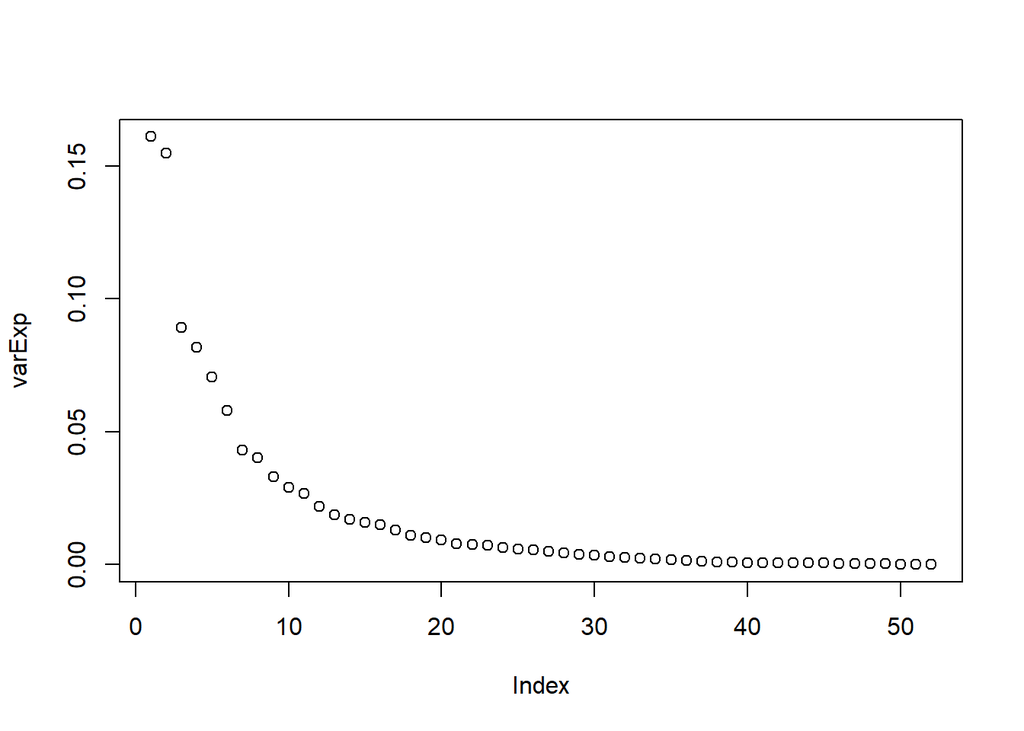

```r
pca <- prcomp(trainingFinal[, -53], scale. = TRUE)
var <- pca$sdev ^ 2
varExp <- var / sum(var)
plot(varExp)
```

However, as we can see, the varExp is relatively distributed out across the principal components, with 25 principal components needed to explain 95% of the variance. If we attempt to train a random forest after PCA, the accuracy is worse:

```r
trainingPCA <- cbind(as.data.frame(pca$x[, 1:25]), classe = trainingFinal$classe)
rfPCA <- train(classe ~., data = trainingPCA, method = "rf", trControl = trainControlCV)
rfPCA$results
```

```
##   mtry  Accuracy     Kappa  AccuracySD     KappaSD
## 1    2 0.9750948 0.9684904 0.002701122 0.003421938
## 2   13 0.9713369 0.9637430 0.003450810 0.004370392
## 3   25 0.9663031 0.9573752 0.003328037 0.004210601
```

```r
decreaseFeatures <- function(number, model) {
  varImpDF <- varImp(model)$importance
  varImpVector <- varImpDF[[1]]
  names(varImpVector) <- row.names(varImpDF)
  varImpVectorSorted <- sort(varImpVector, decreasing = TRUE)
  names <- names(varImpVectorSorted)[1:number]
  subset <- cbind(trainingFinal[, names], classe = trainingFinal$classe)
  newModel <- train(classe ~., data = subset, method = "rf", trControl = trainControlCV, tuneGrid = expand.grid(mtry = c(2)))
  newModel
}
rf0 <- decreaseFeatures(30, rfBase)
rf0$results
```

```
##   mtry Accuracy     Kappa  AccuracySD    KappaSD
## 1    2 0.992038 0.9899283 0.001755396 0.00222143
```

```r
rf1 <- decreaseFeatures(25, rfBase)
rf1$results
```

```
##   mtry  Accuracy    Kappa  AccuracySD     KappaSD
## 1    2 0.9927397 0.990816 0.003149771 0.003984863
```

```r
rf2 <- decreaseFeatures(20, rfBase)
rf2$results
```

```
##   mtry  Accuracy     Kappa  AccuracySD     KappaSD
## 1    2 0.9899994 0.9873494 0.002459022 0.003111608
```

```r
namesFinal <- c(rf1$coefnames, "classe")
rfFinal <- train(classe ~., data = trainingFinal[, namesFinal], method = "rf",
                 trControl = trainControlCV, tuneGrid = expand.grid(mtry = c(2)))
rfFinal$results
```

```
##   mtry  Accuracy     Kappa  AccuracySD     KappaSD
## 1    2 0.9918461 0.9896859 0.002438145 0.003084792
```

Finally, we estimate out-of-sample error for rfBase and rfFinal.

```r
predictBase <- predict(rfBase$finalModel, trainingReserve)
matrixBase <- confusionMatrix(predictBase, trainingReserve$classe)
predictFinal <- predict(rfFinal$finalModel, trainingReserve[, namesFinal])
matrixFinal <- confusionMatrix(predictFinal, trainingReserve$classe)
matrixBase
```

```
## Confusion Matrix and Statistics
##
##           Reference
## Prediction    A    B    C    D    E
##          A 1116    7    0    0    0
##          B    0  750    6    0    0
##          C    0    2  678    9    0
##          D    0    0    0  634    2
##          E    0    0    0    0  719
##
## Overall Statistics
##
##                Accuracy : 0.9934
##                  95% CI : (0.9903, 0.9957)
##     No Information Rate : 0.2845
##     P-Value [Acc > NIR] : < 2.2e-16
##
##                   Kappa : 0.9916
##  Mcnemar's Test P-Value : NA
##
## Statistics by Class:
##
##                      Class: A Class: B Class: C Class: D Class: E
## Sensitivity            1.0000   0.9881   0.9912   0.9860   0.9972
## Specificity            0.9975   0.9981   0.9966   0.9994   1.0000
## Pos Pred Value         0.9938   0.9921   0.9840   0.9969   1.0000
## Neg Pred Value         1.0000   0.9972   0.9981   0.9973   0.9994
## Prevalence             0.2845   0.1935   0.1744   0.1639   0.1838
## Detection Rate         0.2845   0.1912   0.1728   0.1616   0.1833
## Detection Prevalence   0.2863   0.1927   0.1756   0.1621   0.1833
## Balanced Accuracy      0.9988   0.9931   0.9939   0.9927   0.9986
```

```r
matrixFinal
```

```
## Confusion Matrix and Statistics
##
##           Reference
## Prediction    A    B    C    D    E
##          A 1110    6    0    0    0
##          B    5  746    8    0    0
##          C    0    7  676    7    0
##          D    0    0    0  635    2
##          E    1    0    0    1  719
##
## Overall Statistics
##
##                Accuracy : 0.9906
##                  95% CI : (0.987, 0.9934)
##     No Information Rate : 0.2845
##     P-Value [Acc > NIR] : < 2.2e-16
##
##                   Kappa : 0.9881
##  Mcnemar's Test P-Value : NA
##
## Statistics by Class:
##
##                      Class: A Class: B Class: C Class: D Class: E
## Sensitivity            0.9946   0.9829   0.9883   0.9876   0.9972
## Specificity            0.9979   0.9959   0.9957   0.9994   0.9994
## Pos Pred Value         0.9946   0.9829   0.9797   0.9969   0.9972
## Neg Pred Value         0.9979   0.9959   0.9975   0.9976   0.9994
## Prevalence             0.2845   0.1935   0.1744   0.1639   0.1838
## Detection Rate         0.2829   0.1902   0.1723   0.1619   0.1833
## Detection Prevalence   0.2845   0.1935   0.1759   0.1624   0.1838
## Balanced Accuracy      0.9962   0.9894   0.9920   0.9935   0.9983
```

Note that accuracy of our prediction is higher for rfBase compared to rfFinal. Thus, we shall use rfBase with all 52 predictors to train on the validation dataset.